# Participation Rate based on Github Repository Public Events

#### Time Between Releases

How any repos had the majority of releases at a regular interval?

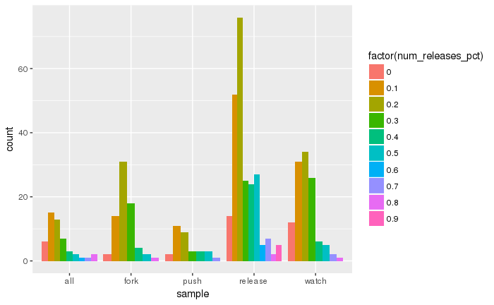

```r
# combine time between releases dataframes
repo_releases_time_between_freq <- bind_rows(all_repo_releases_time_between, push_repo_releases_time_between, watch_repo_releases_time_between, fork_repo_releases_time_between, release_repo_releases_time_between)
# Determine max num releases log and calculate release proportion (for comparability amongs different release frequencies)
# also count the number of buckets so we have an idea of the variability between release times
repo_releases_time_between_freq <- repo_releases_time_between_freq %>%
  ungroup() %>%
  group_by(sample, repo_slug) %>%
  mutate(
    num_releases_log_max = max(num_releases_log),
    num_releases_pct = round(num_releases/total_releases, 1),
    buckets = n()
  )
ggplot(data = repo_releases_time_between_freq,
       aes(x = sample, fill=factor(num_releases_pct))) +
  geom_bar(position="dodge")
```

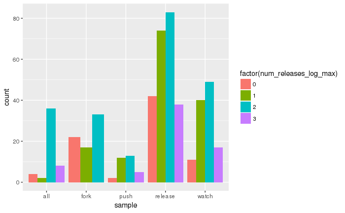

```r
ggplot(data = repo_releases_time_between_freq,
       aes(x = sample, fill=factor(num_releases_log_max))) +
  geom_bar(position="dodge")
```

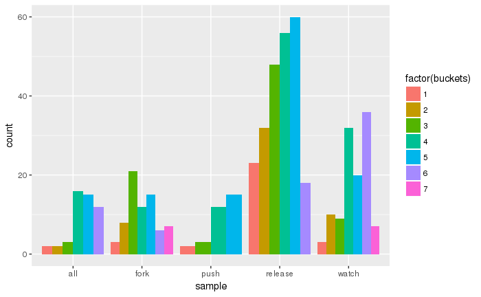

```r
ggplot(data = repo_releases_time_between_freq,
       aes(x = sample, fill=factor(buckets))) +
  geom_bar(position="dodge")
```

Is there any relationship between the number of buckets and the number of releases? That is, do repos that have a large number of releases falling into the same interval tend to do more or less releases?

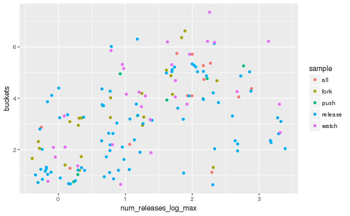

```r
# overall by repo
repo_releases_time_between_freq_by_repo <- repo_releases_time_between_freq %>%
  group_by(sample, repo_slug) %>%
  summarise(
    num_releases_log_max = max(num_releases_log_max),
    buckets = max(buckets)
  )
ggplot(data = repo_releases_time_between_freq_by_repo,
       aes(x=num_releases_log_max, y=buckets, color=sample)) +
  geom_jitter() #+
```

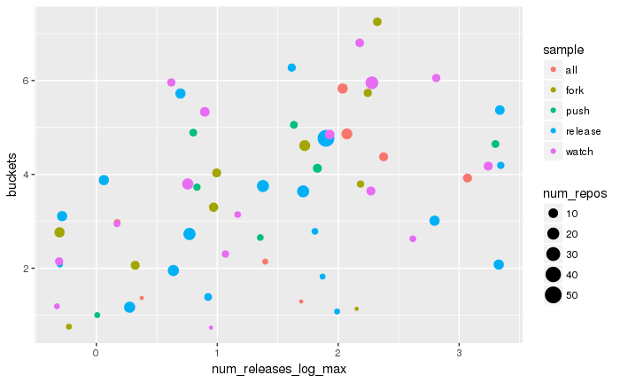

```r
  #theme(legend.position="none")
# by sample
repo_releases_time_between_freq_summary <- repo_releases_time_between_freq %>%
  ungroup() %>%
  group_by(sample, num_releases_log_max, buckets) %>%
  summarise(
    num_repos = n()
  )
ggplot(data = repo_releases_time_between_freq_summary,
       aes(x=num_releases_log_max, y=buckets, size=num_repos, color = sample)) +
  geom_jitter()
```

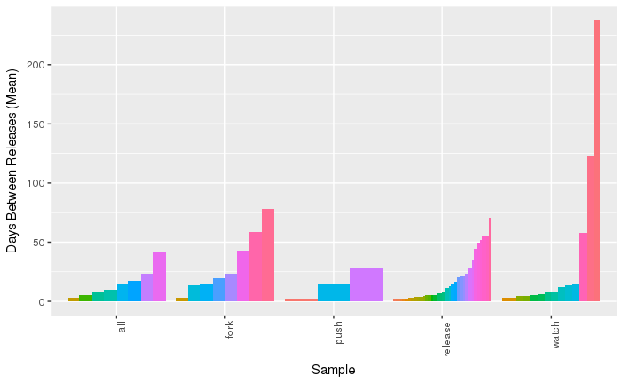

```r
# filter out releases interval buckets that had the max number of releases per repo
# log 0 means only 1 release, so we don't want these as they are not a true "max"
repo_releases_time_between_freq_per_repo_top <- repo_releases_time_between_freq %>%
  filter(num_releases_log == num_releases_log_max & num_releases_log > 0 & published_at_interval_log > 0)
# combine these per repo
repo_releases_time_between_freq_per_repo_top_summary <- repo_releases_time_between_freq_per_repo_top %>%
  group_by(sample, repo_slug, num_releases_log) %>%
  summarise(
    num_releases = sum(num_releases),
    num_releases_pct = round(num_releases/max(total_releases), 1),
    published_at_interval_mmin = min(published_at_interval_mean),
    published_at_interval_mmax = max(published_at_interval_mean),
    published_at_interval_mmean = mean(published_at_interval_mean),
    published_at_interval_log_cnt = n()
  )
ggplot(data = repo_releases_time_between_freq_per_repo_top_summary %>%
         filter(published_at_interval_log_cnt <= 2),
       aes(x=sample,
           y=published_at_interval_mmean,
           fill=reorder(repo_slug, published_at_interval_mmean))) +
  geom_bar(stat="identity", position="dodge") +
  ylab("Days Between Releases (Mean)") +
  xlab("Sample") +
  theme(axis.text.x = element_text(angle = 90, hjust = 1)) +
  theme(legend.position="none")
ggsave("repo_release_time_between_summary_top.png")
```

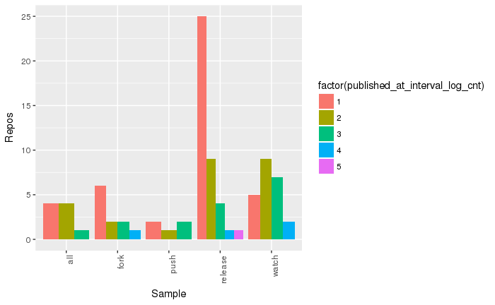

```r
repo_releases_time_between_freq_repo_summary <- repo_releases_time_between_freq_per_repo_top_summary %>%
  ungroup() %>%
  group_by(sample, published_at_interval_log_cnt) %>%
  summarise(
    num_repos = n(),
    num_repos_log = round(log(num_repos)),
    num_releases_pct_min = min(num_releases_pct),
    num_releases_pct_max = max(num_releases_pct),
    published_at_interval_min = min(published_at_interval_mmin),
    published_at_interval_max = max(published_at_interval_mmax)
  ) %>%
  mutate(
    num_releases_min_max = paste(num_releases_pct_min, "-", num_releases_pct_max),
    published_at_interval_min_max = paste(
      round(published_at_interval_min), "-", round(published_at_interval_max))
  )
ggplot(data = repo_releases_time_between_freq_repo_summary,
       aes(x=sample, y=num_repos, fill=factor(published_at_interval_log_cnt))) +
  geom_bar(stat="identity", position="dodge") +
  ylab("Repos") +
  xlab("Sample") +
  theme(axis.text.x = element_text(angle = 90, hjust = 1))
ggsave("repo_release_time_between_summary.png")
```

## README

### All Events

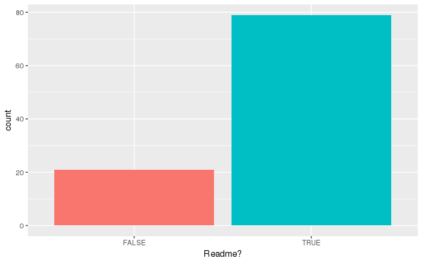

```r
all_repo_readme <- readRDS("all_repo_readme.rds")
all_repo_readme <- all_repo_readme %>%
  mutate(
    has_readme = ifelse(is.na(size), FALSE, TRUE),
    size_log = round(log(size))
  )
# repos with a readme vs repos with no readme
ggplot(data = all_repo_readme,
       aes(x = has_readme,
           fill = factor(has_readme))) +
  geom_bar() +
  theme(legend.position="none") +
  xlab("Readme?")
```

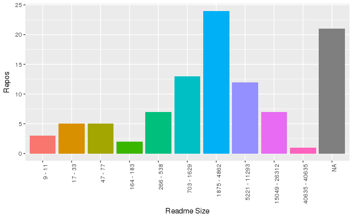

```r
all_repo_readme_size_freq <- all_repo_readme %>%
  group_by(size_log) %>%
  summarise(
    num_repos = n(),
    size_min = min(size),
    size_max = max(size),
    size_min_max = ifelse(is.na(size_min), paste(NA), paste(size_min, "-", size_max)),
    num_repos_log = round(log(num_repos)),
    sample = "all"
  )
ggplot(data = all_repo_readme_size_freq,
       aes(x = reorder(size_min_max, size_log),
           y = num_repos,
           fill = factor(size_log))) +
  geom_bar(stat="identity") +
  theme(legend.position="none") +
  xlab("Readme Size") +
  ylab("Repos") +
  theme(axis.text.x = element_text(angle = 90, hjust = 1))
ggsave("all_repo_readme_size_freq.png")
```

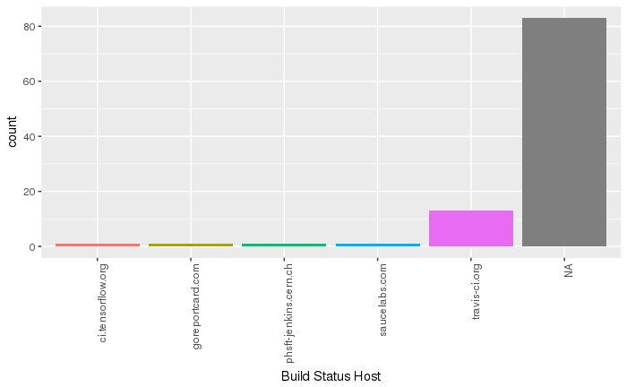

```r
# repos with a build status in the readme
ggplot(data = all_repo_readme,
       aes(x = build_status_host, fill=build_status_host)) +
  geom_bar() +
  theme(legend.position="none") +
  xlab("Build Status Host") +
  theme(axis.text.x = element_text(angle = 90, hjust = 1))
```

```r
all_repo_readme <- all_repo_readme %>%
  mutate(sample = "all")
```

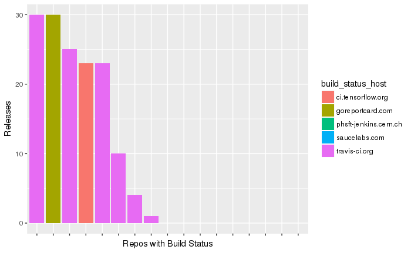

```r
# did any of the repos with build status do releases?
all_repo_has_releases <- all_repo_releases_freq %>%
  select(repo_slug, release_count)
all_repo_readme_sub <- all_repo_readme %>%
  select(repo_slug, has_readme, build_status_host, size, size_log)
all_repo_readme_releases <- merge(all_repo_has_releases, all_repo_readme_sub)
all_repo_readme_releases_true <- all_repo_readme_releases %>%
  mutate(has_build_status=ifelse(is.na(build_status_host), FALSE, TRUE)) %>%
  filter(has_build_status == TRUE)
ggplot(data = all_repo_readme_releases_true,
       aes(x = reorder(repo_slug, -release_count), y = release_count, fill=build_status_host)) +
  geom_bar(stat="identity") +
  xlab("Repos with Build Status") +
  ylab("Releases") +
  theme(axis.text.x = element_blank())
ggsave("all_repo_readme_buildstatus_host.png")
```

### Push Events

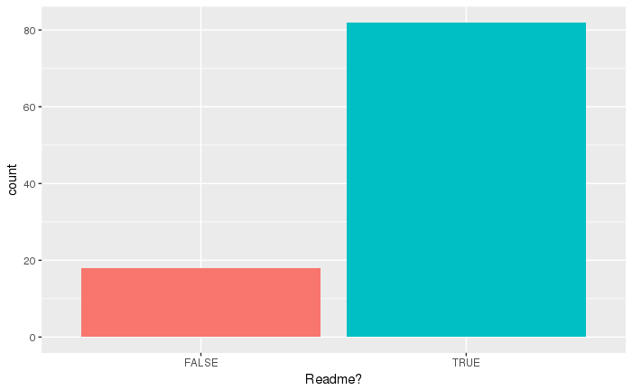

```r
push_repo_readme <- readRDS("push_repo_readme.rds")
push_repo_readme <- push_repo_readme %>%
  mutate(
    has_readme = ifelse(is.na(size), FALSE, TRUE),
    size_log = round(log(size))
  )
# repos with a readme vs repos with no readme
ggplot(data = push_repo_readme,
       aes(x = has_readme,
           fill = factor(has_readme))) +
  geom_bar() +
  theme(legend.position="none") +
  xlab("Readme?")
```

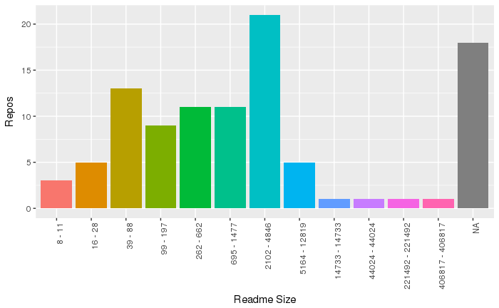

```r
push_repo_readme_size_freq <- push_repo_readme %>%
  group_by(size_log) %>%
  summarise(
    num_repos = n(),
    size_min = min(size),
    size_max = max(size),
    size_min_max = ifelse(is.na(size_min), paste(NA), paste(size_min, "-", size_max)),
    num_repos_log = round(log(num_repos)),
    sample = "push"
  )
ggplot(data = push_repo_readme_size_freq,
       aes(x = reorder(size_min_max, size_log),
           y = num_repos,
           fill = factor(size_log))) +
  geom_bar(stat="identity") +
  theme(legend.position="none") +
  xlab("Readme Size") +
  ylab("Repos") +
  theme(axis.text.x = element_text(angle = 90, hjust = 1))
ggsave("push_repo_readme_size_freq.png")
```

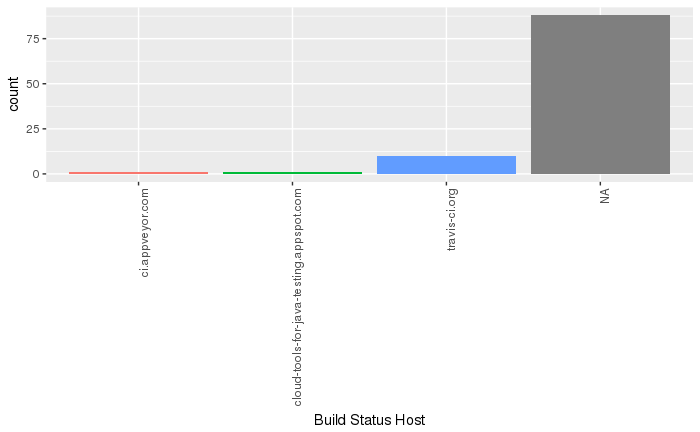

```r
# repos with a build status in the readme
ggplot(data = push_repo_readme,
       aes(x = build_status_host, fill=build_status_host)) +
  geom_bar() +
  theme(legend.position="none") +
  xlab("Build Status Host") +
  theme(axis.text.x = element_text(angle = 90, hjust = 1))
```

```r
push_repo_readme <- push_repo_readme %>%
  mutate(sample = "push")
```

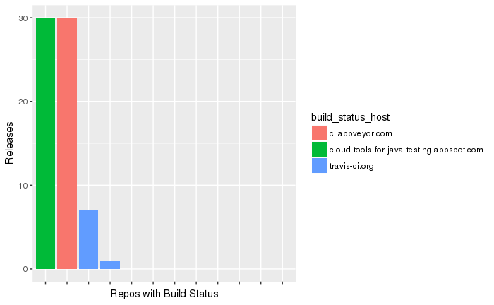

```r
# did any of the repos with build status do releases?
push_repo_has_releases <- push_repo_releases_freq %>%
  select(repo_slug, release_count)
push_repo_readme_sub <- push_repo_readme %>%
  select(repo_slug, has_readme, build_status_host, size, size_log)
push_repo_readme_releases <- merge(push_repo_has_releases, push_repo_readme_sub)
push_repo_readme_releases_true <- push_repo_readme_releases %>%
  mutate(has_build_status=ifelse(is.na(build_status_host), FALSE, TRUE)) %>%
  filter(has_build_status == TRUE)
ggplot(data = push_repo_readme_releases_true,
       aes(x = reorder(repo_slug, -release_count), y = release_count, fill=build_status_host)) +
  geom_bar(stat="identity") +
  xlab("Repos with Build Status") +
  ylab("Releases") +
  theme(axis.text.x = element_blank())
ggsave("push_repo_readme_buildstatus_host.png")
```

### Watch Events

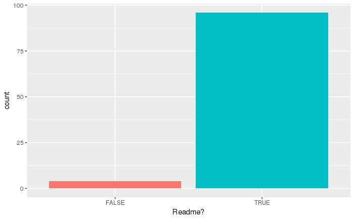

```r
watch_repo_readme <- readRDS("watch_repo_readme.rds")
watch_repo_readme <- watch_repo_readme %>%
  mutate(
    has_readme = ifelse(is.na(size), FALSE, TRUE),
    size_log = round(log(size))
  )
# repos with a readme vs repos with no readme
ggplot(data = watch_repo_readme,
       aes(x = has_readme,
           fill = factor(has_readme))) +
  geom_bar() +
  theme(legend.position="none") +
  xlab("Readme?")
```

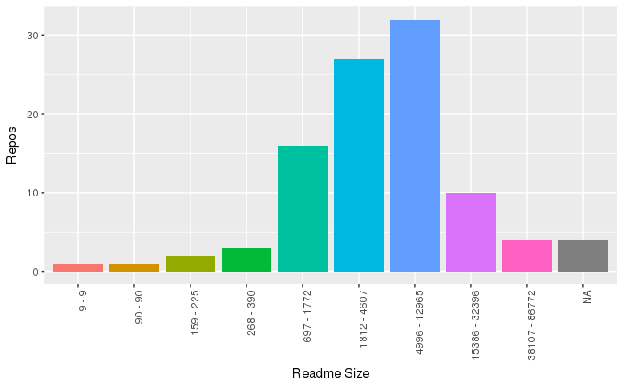

```r
watch_repo_readme_size_freq <- watch_repo_readme %>%
  group_by(size_log) %>%
  summarise(
    num_repos = n(),
    size_min = min(size),
    size_max = max(size),
    size_min_max = ifelse(is.na(size_min), paste(NA), paste(size_min, "-", size_max)),
    num_repos_log = round(log(num_repos)),
    sample = "watch"
  )
ggplot(data = watch_repo_readme_size_freq,
       aes(x = reorder(size_min_max, size_log),
           y = num_repos,
           fill = factor(size_log))) +
  geom_bar(stat="identity") +
  theme(legend.position="none") +
  xlab("Readme Size") +
  ylab("Repos") +
  theme(axis.text.x = element_text(angle = 90, hjust = 1))
ggsave("watch_repo_readme_size_freq.png")
```

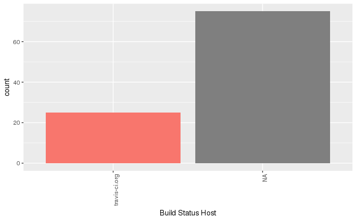

```r
# repos with a build status in the readme
ggplot(data = watch_repo_readme,
       aes(x = build_status_host, fill=build_status_host)) +
  geom_bar() +
  theme(legend.position="none") +
  xlab("Build Status Host") +
  theme(axis.text.x = element_text(angle = 90, hjust = 1))
```

```r
watch_repo_readme <- watch_repo_readme %>%
  mutate(sample = "watch")
```

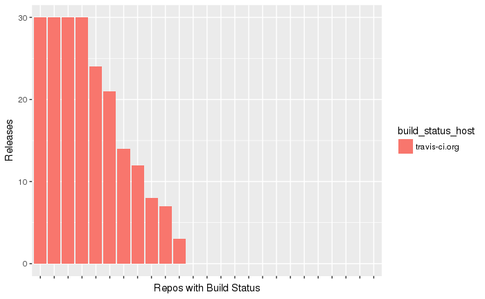

```r
# did any of the repos with build status do releases?
watch_repo_has_releases <- watch_repo_releases_freq %>%
  select(repo_slug, release_count)
watch_repo_readme_sub <- watch_repo_readme %>%
  select(repo_slug, has_readme, build_status_host, size, size_log)
watch_repo_readme_releases <- merge(watch_repo_has_releases, watch_repo_readme_sub)
watch_repo_readme_releases_true <- watch_repo_readme_releases %>%
  mutate(has_build_status=ifelse(is.na(build_status_host), FALSE, TRUE)) %>%
  filter(has_build_status == TRUE)
ggplot(data = watch_repo_readme_releases_true,
       aes(x = reorder(repo_slug, -release_count), y = release_count, fill=build_status_host)) +
  geom_bar(stat="identity") +
  xlab("Repos with Build Status") +
  ylab("Releases") +
  theme(axis.text.x = element_blank())
ggsave("watch_repo_readme_buildstatus_host.png")
```

### Fork Events

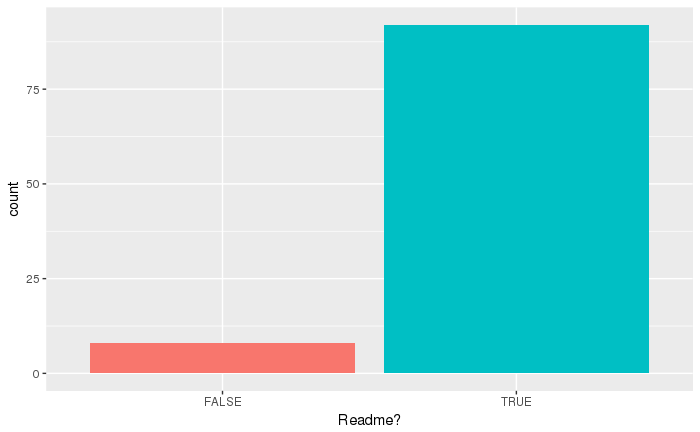

```r
fork_repo_readme <- readRDS("fork_repo_readme.rds")
fork_repo_readme <- fork_repo_readme %>%
  mutate(
    has_readme = ifelse(is.na(size), FALSE, TRUE),
    size_log = round(log(size))
  )
# repos with a readme vs repos with no readme
ggplot(data = fork_repo_readme,
       aes(x = has_readme,
           fill = factor(has_readme))) +
  geom_bar() +
  theme(legend.position="none") +
  xlab("Readme?")
```

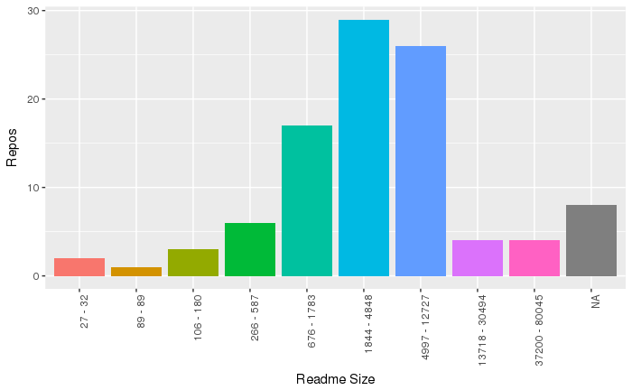

```r
fork_repo_readme_size_freq <- fork_repo_readme %>%
  group_by(size_log) %>%
  summarise(
    num_repos = n(),
    size_min = min(size),
    size_max = max(size),
    size_min_max = ifelse(is.na(size_min), paste(NA), paste(size_min, "-", size_max)),
    num_repos_log = round(log(num_repos)),
    sample = "fork"
  )
ggplot(data = fork_repo_readme_size_freq,
       aes(x = reorder(size_min_max, size_log),
           y = num_repos,
           fill = factor(size_log))) +
  geom_bar(stat="identity") +
  theme(legend.position="none") +
  xlab("Readme Size") +
  ylab("Repos") +
  theme(axis.text.x = element_text(angle = 90, hjust = 1))
ggsave("fork_repo_readme_size_freq.png")
```

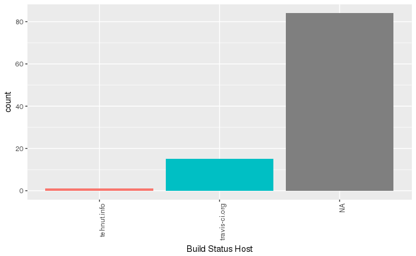

```r
# repos with a build status in the readme
ggplot(data = fork_repo_readme,
       aes(x = build_status_host, fill=build_status_host)) +
  geom_bar() +
  theme(legend.position="none") +
  xlab("Build Status Host") +
  theme(axis.text.x = element_text(angle = 90, hjust = 1))
```

```r
fork_repo_readme <- fork_repo_readme %>%
  mutate(sample = "fork")
```

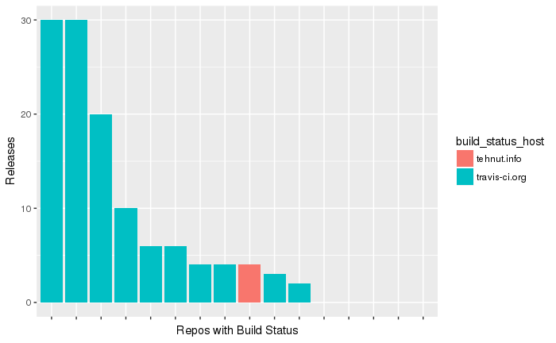

```r
# did any of the repos with build status do releases?
fork_repo_has_releases <- fork_repo_releases_freq %>%
  select(repo_slug, release_count)
fork_repo_readme_sub <- fork_repo_readme %>%
  select(repo_slug, has_readme, build_status_host, size, size_log)
fork_repo_readme_releases <- merge(fork_repo_has_releases, fork_repo_readme_sub)
fork_repo_readme_releases_true <- fork_repo_readme_releases %>%
  mutate(has_build_status=ifelse(is.na(build_status_host), FALSE, TRUE)) %>%
  filter(has_build_status == TRUE)
ggplot(data = fork_repo_readme_releases_true,
       aes(x = reorder(repo_slug, -release_count), y = release_count, fill=build_status_host)) +
  geom_bar(stat="identity") +
  xlab("Repos with Build Status") +
  ylab("Releases") +
  theme(axis.text.x = element_blank())
ggsave("fork_repo_readme_buildstatus_host.png")
```

### Release Events

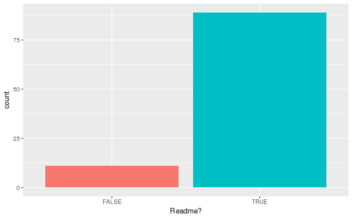

```r
release_repo_readme <- readRDS("release_repo_readme.rds")
release_repo_readme <- release_repo_readme %>%
  mutate(
    has_readme = ifelse(is.na(size), FALSE, TRUE),
    size_log = round(log(size))
  )
# repos with a readme vs repos with no readme
ggplot(data = release_repo_readme,
       aes(x = has_readme,
           fill = factor(has_readme))) +
  geom_bar() +
  theme(legend.position="none") +
  xlab("Readme?")
```

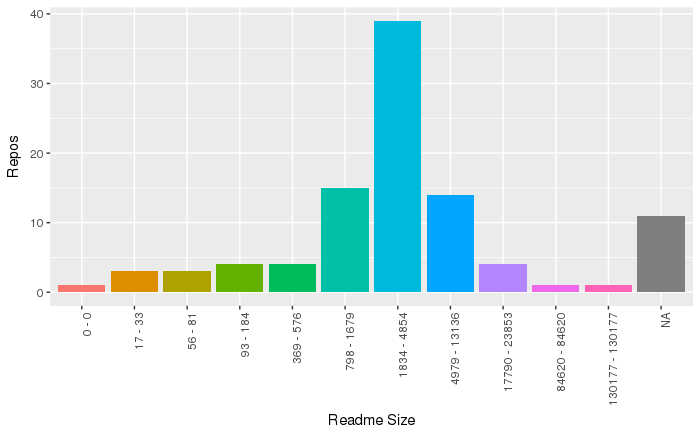

```r
release_repo_readme_size_freq <- release_repo_readme %>%
  group_by(size_log) %>%
  summarise(
    num_repos = n(),
    size_min = min(size),
    size_max = max(size),
    size_min_max = ifelse(is.na(size_min), paste(NA), paste(size_min, "-", size_max)),
    num_repos_log = round(log(num_repos)),
    sample = "release"
  )
ggplot(data = release_repo_readme_size_freq,
       aes(x = reorder(size_min_max, size_log),
           y = num_repos,
           fill = factor(size_log))) +
  geom_bar(stat="identity") +
  theme(legend.position="none") +
  xlab("Readme Size") +
  ylab("Repos") +
  theme(axis.text.x = element_text(angle = 90, hjust = 1))
ggsave("release_repo_readme_size_freq.png")
```

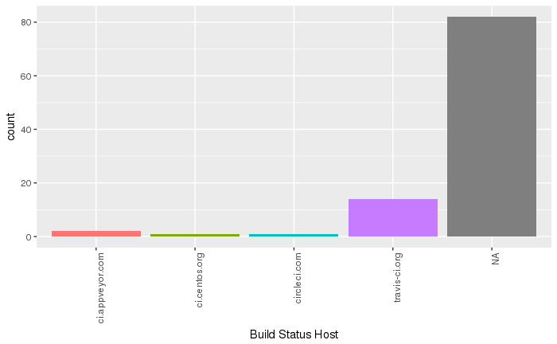

```r
# repos with a build status in the readme
ggplot(data = release_repo_readme,
       aes(x = build_status_host, fill=build_status_host)) +
  geom_bar() +
  theme(legend.position="none") +
  xlab("Build Status Host") +
  theme(axis.text.x = element_text(angle = 90, hjust = 1))
```

```r
release_repo_readme <- release_repo_readme %>%
  mutate(sample = "release")
```

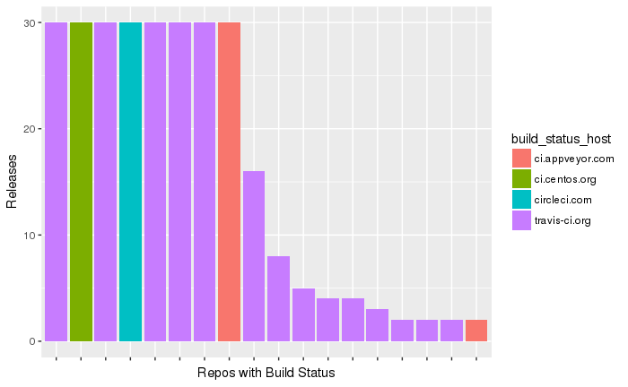

```r
# did any of the repos with build status do releases?
release_repo_has_releases <- release_repo_releases_freq %>%
  select(repo_slug, release_count)
release_repo_readme_sub <- release_repo_readme %>%
  select(repo_slug, has_readme, build_status_host, size, size_log)
release_repo_readme_releases <- merge(release_repo_has_releases, release_repo_readme_sub)
release_repo_readme_releases_true <- release_repo_readme_releases %>%
  mutate(has_build_status=ifelse(is.na(build_status_host), FALSE, TRUE)) %>%
  filter(has_build_status == TRUE)
ggplot(data = release_repo_readme_releases_true,
       aes(x = reorder(repo_slug, -release_count), y = release_count, fill=build_status_host)) +
  geom_bar(stat="identity") +
  xlab("Repos with Build Status") +
  ylab("Releases") +
  theme(axis.text.x = element_blank())
ggsave("release_repo_readme_buildstatus_host.png")
```

### Summary

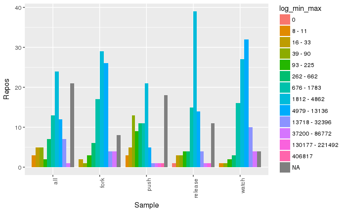

```r
repo_readme_size_freq <- bind_rows(all_repo_readme_size_freq, push_repo_readme_size_freq,
                        watch_repo_readme_size_freq, fork_repo_readme_size_freq, release_repo_readme_size_freq)
repo_readme_size_freq <- repo_readme_size_freq %>%
  mutate(num_repos_log = round(log(num_repos)))
repo_readme_size_freq_log <- repo_readme_size_freq %>%
  group_by(size_log) %>%
  summarise(
    log_min = min(size_min),
    log_max = max(size_max)) %>%
  mutate(log_min_max = ifelse(log_min == log_max,
                         log_max,
                         paste(log_min,"-",log_max)))
repo_readme_size_freq <- merge(repo_readme_size_freq_log, repo_readme_size_freq, by="size_log")
repo_readme_size_freq$log_min_max <- factor(repo_readme_size_freq$log_min_max,
                                       levels=unique(
                                           repo_readme_size_freq$log_min_max[
                                             order(repo_readme_size_freq$size_log)]))
ggplot(data = repo_readme_size_freq,
       aes(x=sample, y=num_repos, fill=log_min_max)) +
  geom_bar(stat="identity", position="dodge") +
  ylab("Repos") +
  xlab("Sample") +
  theme(axis.text.x = element_text(angle = 90, hjust = 1))
ggsave("repo_readme_size_freq.png")
```

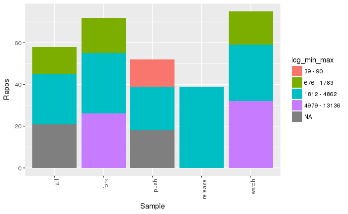

```r
repo_readme_size_freq <- repo_readme_size_freq %>%
  group_by(sample) %>%
  mutate(num_repos_log_max = max(num_repos_log))
repo_readme_size_freq_summary_top <- repo_readme_size_freq %>%
  filter(num_repos_log == num_repos_log_max)
ggplot(data = repo_readme_size_freq_summary_top,
       aes(x=sample, y=num_repos, fill=log_min_max)) +
  geom_bar(stat="identity", position="stack") +
  ylab("Repos") +
  xlab("Sample") +
  theme(axis.text.x = element_text(angle = 90, hjust = 1))
ggsave("repo_readme_size_freq_top.png")
```

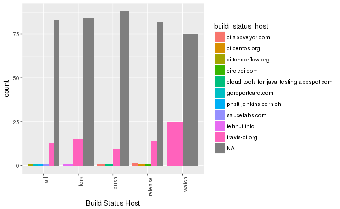

```r
repo_readme <- bind_rows(all_repo_readme, push_repo_readme,
                        watch_repo_readme, fork_repo_readme, release_repo_readme)
ggplot(data = repo_readme,
       aes(x = sample, fill=build_status_host)) +
  geom_bar(position="dodge") +
  xlab("Build Status Host") +
  theme(axis.text.x = element_text(angle = 90, hjust = 1))
ggsave("repo_readme_host.png")
```

# Conclusions

Some Github API parameters unrelated to the event data showed a consistent pattern that correlated with the event type. Specifically, Age, Readme size, Releases, Build status in Readme (somewhat) had the strongest correlation to event type.

The Watch sample showed a consistent skew throughout all parameters. Therefore, a sample of repos using Watch events will bias towards the type of repos we are interested in studying while still representing the overall Github population in a way that can be accounted for.